# Titanic: logistic regression

```r
rm(list=ls())
library(tidyverse)
```

1. Load the Titanic dataset.

```r
df <- read.csv("data/titanic.csv")
```

2. Make a plot of the fraction surviving in each class

```r
df %>%
  group_by(Pclass) %>%
  summarise(Survived=sum(Survived),
            n=n()) %>%
  mutate(lower=qbeta(0.025, 1 + Survived, 1 + n - Survived),
         upper=qbeta(0.975, 1 + Survived, 1 + n - Survived),
         middle=qbeta(0.5, 1 + Survived, 1 + n - Survived)) %>%
  ggplot(aes(x=as.factor(Pclass), y=middle)) +
  geom_pointrange(aes(ymin=lower, ymax=upper)) +
  xlab("Passenger class") +
  ylab("Percentage surviving") +
  scale_y_continuous(labels=scales::percent_format(accuracy=1))
```

[output not shown]

3. In this practical, we are going to create a logistic regression model and use it to investigate how passenger class influenced survival probabilities. To do so, we are actually going to use dummy variables for the classes: binary variables which take on the value 0 if not true and 1 if true.

Create dummy variables for classes 1 and 2. This implicitly means that the 3rd class will be the base case that we compare to.

```r
df <- df %>%
  mutate(class_1=if_else(Pclass==1, 1, 0),
         class_2=if_else(Pclass==2, 1, 0))
```

4. Write an R function for the logistic function: $\theta = \frac{1}{1 + \exp(-x)}$. The function takes $x$ as its sole argument.

```r
logistic <- function(x) {1 / (1 + exp(-x))}
```

5. Plot the logistic function for $x\in[-8,8]$.

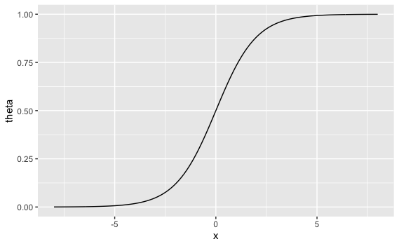

```r
x <- seq(-8, 8, length.out = 1000)
theta <- logistic(x)
tibble(x, theta) %>%
  ggplot(aes(x, theta)) +
  geom_line()
```

6. We are going to use the logistic function to represent the probability of a passenger surviving. But to do so, we need to write a function which returns the linear combination of $\beta_0 + \beta_1 z_1 + \beta_2 z_2$. The function should take as input $\beta_0, \beta_1, \beta_2$ (the regression parameters) and the covariates $z_1$ and $z_2$.

```r
linear_combination <- function(beta_0, beta_1, beta_2, z_1, z_2) {
  beta_0 + beta_1 * z_1 + beta_2 * z_2
}
```

7. Write a function which returns the probability:

$$\theta_i = \text{logistic}(\beta_0 + \beta_1 z_1 + \beta_2 z_2)$$
where “logistic” is the function you created above. The function should takes as input $\beta_0, \beta_1, \beta_2$ (the regression parameters) and the covariates $z_1$ and $z_2$.

```r
probability <- function(beta_0, beta_1, beta_2, z_1, z_2) {
  logistic(linear_combination(beta_0, beta_1, beta_2, z_1, z_2))
}
```

8. We are now going to write a function which returns the log-likelihood for a single set, $i$, of data points: $(z_{1i}, z_{2i}, S_i)$ where $S_i\in\{0,1\}$ represents whether a passenger survived. In logistic regression, we assume that $S_i\sim \text{Bernoulli}(\theta_i)$. This means that the likelihood, $\mathcal{L}_i$, for a single set of data points is given by:

$$\theta_i = \text{logistic}(\beta_0 + \beta_1 z_1 + \beta_2 z_2)\\
\mathcal{L}_i = \theta_i^{S_i} (1 - \theta_i)^{1-S_i}$$
9. Write a function with takes as input $\beta_0, \beta_1, \beta_2$ (the regression parameters), the covariates $z_1$ and $z_2$ and (crucially!) a value of $S_i$ and returns $\mathcal{L}_i$.

```r
likelihood_single <- function(S_i, beta_0, beta_1, beta_2, z_1, z_2) {
  theta_i <- probability(beta_0, beta_1, beta_2, z_1, z_2)
  theta_i^S_i * (1 - theta_i)^(1 - S_i)
}
```

10. The overall likelihood of observations is given by the product of the individual likelihoods of each data point, since we assume that the data are (conditionally) independent given the parameters:

$$\mathcal{L} = \prod_{i=1}^N \mathcal{L}_i$$

11. Write a function that takes as input your processed Titanic dataset and the parameters $\beta_0, \beta_1, \beta_2$ and returns the likelihood. In calculating the likelihood, specify that $z_1$ and $z_2$ should be your class dummies.

```r
likelihood <- function(beta_0, beta_1, beta_2, df) {
  val <- 1
  for(i in seq_along(df$Survived)) {
    row <- df[i, ]
    val <- val * likelihood_single(row$Survived, beta_0, beta_1, beta_2,
                                   row$class_1, row$class_2)
  }
  val
}
```

12. We are now going to try to estimate the parameters $\beta_0$ and $\beta_1$ by doing a grid search. We start by fixing $\beta_0=-1.14$ (this is the maximum likelihood value of the parameter). We are then going to do a grid search across all combinations of the following values of $\beta_1=(0, 1, 1.67, 2, 2.5)$ and $\beta_2=(-1, 0, 1, 2, 3)$. For each of the 25 combinations of both sets of parameters, calculate the likelihood. In doing so, find parameters that are close to the maximum likelihood values.

```r
beta_1 <- c(0, 1, 1.67, 2, 2.5)
beta_2 <- c(-1, 0, 1, 2, 3)
parameters <- expand_grid(beta_1, beta_2)
parameters$log_likelihood <- NA
for(i in seq_along(parameters$beta_1)) {
  parameters$log_likelihood[i] <- likelihood(-1.14,
                                             parameters$beta_1[i],
                                             parameters$beta_2[i],
                                             df)
}
max_likelihood <- parameters[which.max(parameters$log_likelihood), ]
max_likelihood
```

| beta_1 | beta_2 | log_likelihood |
| --- | --- | --- |
| 1.67 | 1 | 6.257358e-236 |

13. Run the following code which does maximum likelihood estimation for you. Compare the estimates below with your ones above.

```r
glm(Survived~class_1+class_2, data=df, family="binomial")
```

```
Call:  glm(formula = Survived ~ class_1 + class_2, family = "binomial",
    data = df)

Coefficients:
(Intercept)      class_1      class_2
     -1.140        1.670        1.031

Degrees of Freedom: 890 Total (i.e. Null);  888 Residual
Null Deviance:      1187
Residual Deviance: 1083     AIC: 1089
```

14. What do your estimates suggest are the odds ratios for survival relative to 3rd class passengers for being in 1st and 2nd classes respectively?

The odds ratios are given by the exponent of the estimates.

```r
exp(max_likelihood$beta_1)
```

```
[1] 5.312168
```

```r
exp(max_likelihood$beta_2)
```

```
[1] 2.718282
```

15. What does your model predict is the change in probability of survival in moving from 3rd to 2nd class?

```r
beta_0 <- -1.14
beta_1 <- max_likelihood$beta_1
beta_2 <- max_likelihood$beta_2
# 3rd class survival: base case so both dummies are zero
survival_3 <- probability(beta_0, beta_1, beta_2, 0, 0)
print(paste0("3rd class survival prob: ", round(survival_3, 2)))
```

```
[1] "3rd class survival prob: 0.24"
```

```r
# 2nd class survival
survival_2 <- probability(beta_0, beta_1, beta_2, 0, 1)
print(paste0("2nd class survival prob: ", round(survival_2, 2)))
```

```
[1] "2nd class survival prob: 0.47"
```

```r
print(paste0("Change in survival prob: ", round(survival_2 - survival_3, 2)))
```

```
[1] "Change in survival prob: 0.22"
```

16. What is the change in probability in moving from 2nd to 1st class?

```r
survival_1 <- probability(beta_0, beta_1, beta_2, 1, 0)
print(paste0("1st class survival prob: ", round(survival_1, 2)))
```

```
[1] "1st class survival prob: 0.63"
```

```r
print(paste0("Change in survival prob: ", round(survival_1 - survival_2, 2)))
```

```
[1] "Change in survival prob: 0.16"
```